# Náhodná veličina

Kateřina Večerková vecerkok@vscht.cz

2025-06-26

# Náhodná veličina, PMF, PDF a CDF

## Úvod

V tomto tutoriálu se seznámíme s pojmem náhodné veličiny ve statistice, pochopíme její typy a naučíme se s nimi pracovat v R. Na konci této lekce byste měli být schopni definovat náhodné veličiny, rozlišovat mezi diskrétními a spojitými veličinami a modelovat pravděpodobnostní rozdělení pomocí jazyka R.

## Co je náhodná veličina?

Náhodná veličina je číselný výsledek náhodného procesu. Například při hodu mincí můžeme přiřadit výstupům (panna nebo orel) číselné hodnoty.

- **Diskrétní náhodná veličina:** veličina, která může nabývat konečného nebo spočetného počtu hodnot (např. počet panen při pěti hodech mincí).
- **Spojitá náhodná veličina:** veličina, která může nabývat nekonečně mnoha hodnot v daném intervalu (např. výška studentů ve třídě).

## Diskrétní náhodné veličiny

Diskrétní náhodné veličiny mohou nabývat konečného množství hodnot. Např. hod kostkou může vést k hodnotám od 1 do 6.

```r
# simulace hodu kostkou
set.seed(42) # pevné semínko pro opakovatelnost
rolls <- sample(1:6, size = 1000, replace = TRUE)
table(rolls)
```

```
## rolls
##   1   2   3   4   5   6
## 172 192 164 157 153 162
```

### **Pravděpodobnostní funkce (PMF)**

- **Definice:** Pravděpodobnostní funkce (PMF) popisuje pravděpodobnostní rozdělení diskrétní náhodné veličiny a přiřazuje pravděpodobnosti jednotlivým hodnotám. Vyjadřuje pravděpodobnost, že veličina nabude konkrétní hodnoty.
- **Vlastnosti:** PMF je nezáporná a součet všech pravděpodobností je roven 1.

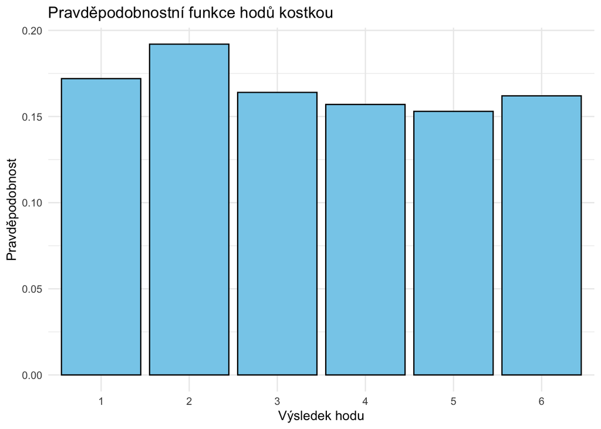

```r
library(ggplot2)

# vykreslení PMF hodů kostkou
rolls_data <- as.data.frame(table(rolls))
colnames(rolls_data) <- c("roll", "frequency")
rolls_data$roll <- as.factor(rolls_data$roll)
rolls_data$probability <- rolls_data$frequency / sum(rolls_data$frequency)

ggplot(rolls_data, aes(x = roll, y = probability)) +
  geom_bar(stat = "identity", fill = "skyblue", color = "black") +
  labs(title = "Pravděpodobnostní funkce hodů kostkou",
       x = "Výsledek hodu",
       y = "Pravděpodobnost") +
  theme_minimal()
```

### **Distribuční funkce (CDF) pro diskrétní veličiny**

- **Definice:** Distribuční funkce (CDF) udává pravděpodobnost, že náhodná veličina nabude hodnoty menší nebo rovné než dané x.
- **Vztah k PMF:** CDF je součtem pravděpodobností z PMF.
- **Vlastnosti:** CDF je nezáporná, neklesající, pravostranně spojitá, začíná na 0 a konverguje k 1.

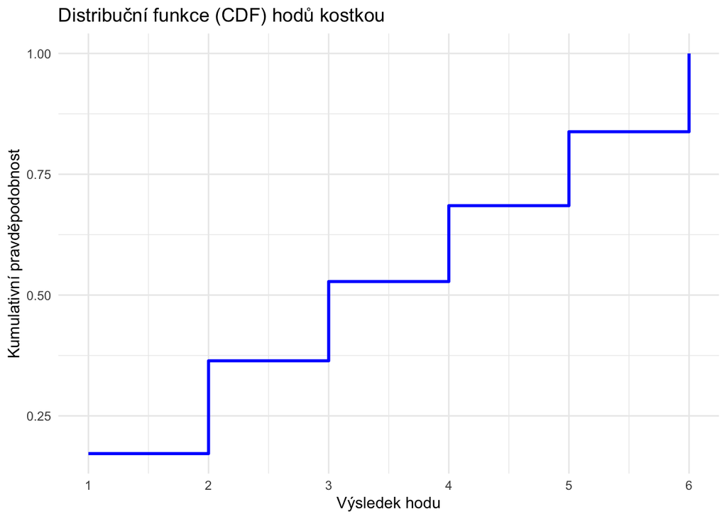

```r
# výpočet kumulativní pravděpodobnosti
rolls_data$cumulative_probability <- cumsum(rolls_data$probability)

# vykreslení CDF pomocí schodového grafu
ggplot(rolls_data, aes(x = as.numeric(as.character(roll)), y = cumulative_probability)) +
  geom_step(color = 'blue', size = 1) +
  labs(title = "Distribuční funkce (CDF) hodů kostkou",
       x = "Výsledek hodu",
       y = "Kumulativní pravděpodobnost") +
  scale_x_continuous(breaks = 1:6) +
  theme_minimal()
```

**Pozor! Graf výše není zcela přesný – dokážete říct proč?**

## Spojité náhodné veličiny

Spojité náhodné veličiny mohou nabývat jakékoli hodnoty v určitém intervalu. Například výška studentů.

```r
# simulace výšek studentů
heights <- rnorm(1000, mean=170, sd=10)
heights[1:10] # prvních deset hodnot
```

```
##  [1] 153.9746 156.4540 139.8207 178.3124 172.5110 174.6229 178.4479 169.5803
##  [9] 158.9442 175.6378
```

### **Hustota pravděpodobnosti (PDF)**

- **Definice:** Hustota pravděpodobnosti (PDF) popisuje pravděpodobnostní rozdělení spojité náhodné veličiny. Neudává pravděpodobnost přímo, ale oblast pod křivkou v určitém intervalu představuje pravděpodobnost, že hodnota padne do tohoto intervalu. Pravděpodobnost přesně jedné hodnoty je nulová.
- **Vlastnosti:** PDF je nezáporná a plocha pod křivkou je rovna 1.

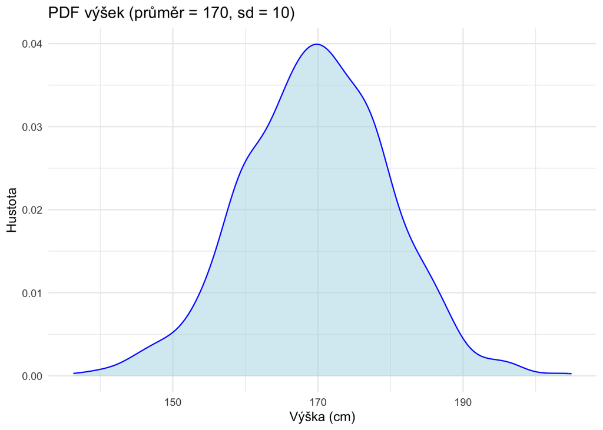

```r
# vykreslení hustoty pravděpodobnosti výšek
ggplot(data.frame(heights = heights), aes(x = heights)) +
  geom_density(color = 'blue', fill = 'lightblue', alpha = 0.5) +
  labs(title = "PDF výšek (průměr = 170, sd = 10)",
       x = "Výška (cm)", y = "Hustota") +
  theme_minimal()
```

### **Distribuční funkce (CDF) pro spojité veličiny**

- **Definice:** Distribuční funkce (CDF) u spojitých veličin udává pravděpodobnost, že náhodná veličina nabude hodnoty menší nebo rovné než x.
- **Vztah k PDF:** CDF se získává integrací PDF.
- **Vlastnosti:** Neklesající, pravostranně spojitá, od 0 do 1.

```r
library(magrittr)
library(tidyverse)
```

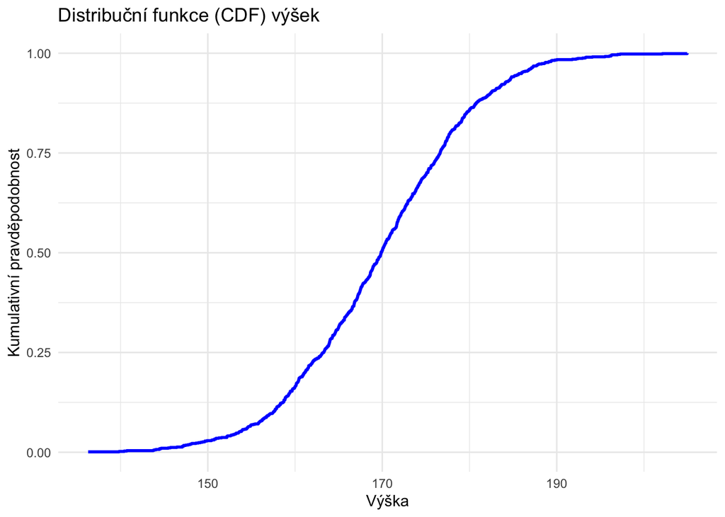

```r
# výpočet CDF
heights_data <- data.frame(heights = heights)
heights_data <- heights_data %>% arrange(heights)
heights_data$cdf <- (1:nrow(heights_data)) / nrow(heights_data)

# vykreslení CDF
ggplot(heights_data, aes(x = heights, y = cdf)) +
  geom_step(color = 'blue', size = 1) +
  labs(title = "Distribuční funkce (CDF) výšek",
       x = "Výška",
       y = "Kumulativní pravděpodobnost") +
  theme_minimal()
```